# Linear Regression and Cousins

```r
library(AppliedPredictiveModeling); library(caret); library(MASS); library(pls); library(elasticnet)
data(solubility)
## The data objects begin with "sol"
ls(pattern = "^solT")
```

```
## [1] "solTestX"       "solTestXtrans"  "solTestY"       "solTrainX"
## [5] "solTrainXtrans" "solTrainY"
```

- Each column corresponds to a predictor, rows correspond to compounds. There are 228 columns in data

```r
set.seed(2)
sample(names(solTrainX), 8)
```

```
## [1] "FP043"        "FP160"        "FP130"        "FP038"
## [5] "NumBonds"     "NumNonHAtoms" "FP029"        "FP185"
```

```r
summary(solTrainX[names(sample((solTrainX), 8))])
```

```
##      FP107            FP125         SurfaceArea1        FP054
##  Min.   :0.0000   Min.   :0.0000   Min.   :  0.00   Min.   :0.00000
##  1st Qu.:0.0000   1st Qu.:0.0000   1st Qu.:  9.23   1st Qu.:0.00000
##  Median :0.0000   Median :0.0000   Median : 29.10   Median :0.00000
##  Mean   :0.2114   Mean   :0.1556   Mean   : 36.46   Mean   :0.07571
##  3rd Qu.:0.0000   3rd Qu.:0.0000   3rd Qu.: 53.28   3rd Qu.:0.00000
##  Max.   :1.0000   Max.   :1.0000   Max.   :331.94   Max.   :1.00000
##      FP171            FP041             FP090            FP189
##  Min.   :0.0000   Min.   :0.00000   Min.   :0.0000   Min.   :0.00000
##  1st Qu.:0.0000   1st Qu.:0.00000   1st Qu.:0.0000   1st Qu.:0.00000
##  Median :0.0000   Median :0.00000   Median :0.0000   Median :0.00000
##  Mean   :0.1693   Mean   :0.06309   Mean   :0.2492   Mean   :0.07676
##  3rd Qu.:0.0000   3rd Qu.:0.00000   3rd Qu.:0.0000   3rd Qu.:0.00000
##  Max.   :1.0000   Max.   :1.00000   Max.   :1.0000   Max.   :1.00000
```

- FP columns correpond to binary 0/1 fingerprints.
- Alterantive versions of data are contained in solTrainXtrans and solTrainXtest; the continuous predictors have been transformed with box-cox.
- solubility values are in solTrainY and solTestY

### Ordinary Linear Regression

```r
# make a data frame with predictors and outcome
trainingData <- solTrainXtrans
trainingData$Solubility <- solTrainY

# simple to fit (without caret)
lmFitAllPredictors <- lm(Solubility ~ ., data = trainingData)
summary(lmFitAllPredictors)
```

```
##
## Call:
## lm(formula = Solubility ~ ., data = trainingData)
##
## Residuals:
##      Min       1Q   Median       3Q      Max
## -1.75620 -0.28304  0.01165  0.30030  1.54887
##
## Coefficients:
##                     Estimate Std. Error t value Pr(>|t|)
## (Intercept)        2.431e+00  2.162e+00   1.124 0.261303
## FP001              3.594e-01  3.185e-01   1.128 0.259635
## FP002              1.456e-01  2.637e-01   0.552 0.580960
## FP003             -3.969e-02  1.314e-01  -0.302 0.762617
## FP004             -3.049e-01  1.371e-01  -2.223 0.026520 *
## FP005              2.837e+00  9.598e-01   2.956 0.003223 **
## FP006             -6.886e-02  2.041e-01  -0.337 0.735917
## FP007              4.044e-02  1.152e-01   0.351 0.725643
## FP008              1.121e-01  1.636e-01   0.685 0.493331
## FP009             -8.242e-01  8.395e-01  -0.982 0.326536
## FP010              4.193e-01  3.136e-01   1.337 0.181579
## FP011              5.158e-02  2.198e-01   0.235 0.814503
## FP012             -1.346e-02  1.611e-01  -0.084 0.933452
## FP013             -4.519e-01  5.473e-01  -0.826 0.409311
## FP014              3.281e-01  4.550e-01   0.721 0.471044
## FP015             -1.839e-01  1.521e-01  -1.209 0.226971
## FP016             -1.367e-01  1.548e-01  -0.883 0.377340
## FP017             -1.704e-01  1.386e-01  -1.230 0.219187
## FP018             -3.824e-01  2.388e-01  -1.602 0.109655
## FP019             -3.131e-01  3.863e-01  -0.811 0.417862
## FP020              2.072e-01  2.135e-01   0.971 0.332078
## FP021             -5.956e-02  2.632e-01  -0.226 0.821060
## FP022              2.336e-01  3.456e-01   0.676 0.499180
## FP023             -3.193e-01  1.909e-01  -1.672 0.094866 .
## FP024             -4.272e-01  2.827e-01  -1.511 0.131162
## FP025              4.376e-01  4.538e-01   0.964 0.335184
## FP026              2.068e-01  2.564e-01   0.806 0.420273
## FP027              2.424e-01  2.429e-01   0.998 0.318594
## FP028              1.070e-01  1.200e-01   0.892 0.372547
## FP029             -9.857e-02  2.199e-01  -0.448 0.654163
```

[output cut: 190 more lines]

```
## NumNitrogen        6.125e+00  3.045e+00   2.011 0.044645 *
## NumOxygen          2.389e+00  4.523e-01   5.283 1.69e-07 ***
## NumSulfer         -8.508e+00  3.619e+00  -2.351 0.018994 *
## NumChlorine       -7.449e+00  1.989e+00  -3.744 0.000195 ***
## NumHalogen         1.408e+00  2.109e+00   0.668 0.504615
## NumRings           1.276e+00  6.716e-01   1.901 0.057731 .
## HydrophilicFactor  1.099e-02  1.137e-01   0.097 0.922998
## SurfaceArea1       8.825e-02  6.058e-02   1.457 0.145643
## SurfaceArea2       9.555e-02  5.615e-02   1.702 0.089208 .
## ---
## Signif. codes:  0 '***' 0.001 '**' 0.01 '*' 0.05 '.' 0.1 ' ' 1
##
## Residual standard error: 0.5524 on 722 degrees of freedom
## Multiple R-squared:  0.9446, Adjusted R-squared:  0.9271
## F-statistic: 54.03 on 228 and 722 DF,  p-value: < 2.2e-16
```

```r
# note there has been no cross validation - RMSE and R^2 are likely optimistically high

# predict
lmPred1 <- predict(lmFitAllPredictors, solTestXtrans)
head(lmPred1)
```

```
##          20          21          23          25          28          31
##  0.99370933  0.06834627 -0.69877632  0.84796356 -0.16578324  1.40815083
```

```r
# collect the observed and predicted values, use caret defaultSummary()
lmValues1 <- data.frame(obs = solTestY, pred = lmPred1)
defaultSummary(lmValues1)
```

```
##      RMSE  Rsquared
## 0.7455802 0.8722236
```

- based on the test set, the summaries produced by the summary function for lm() were optimistic.
- if wasnt a robust linear model, use rlm() from MASS package, which by degault employs the Huber approach

```r
rlmFitAllPredictors <- rlm(Solubility ~ ., data = trainingData)
```

- caret train() function can be used. 10-fold cross validatio should be reasonable, as not small training set. trainControl() specifies resampling

```r
ctrl <- trainControl(method = "cv", number = 10)

# use train to fit
set.seed(100)
lmFit1 <- train(x = solTrainXtrans, y = solTrainY,
                method = "lm", trControl = ctrl)
lmFit1
```

```
## Linear Regression
##
## 951 samples
## 228 predictors
##
## No pre-processing
## Resampling: Cross-Validated (10 fold)
##
## Summary of sample sizes: 856, 856, 856, 856, 856, 855, ...
##
## Resampling results
##
##   RMSE       Rsquared   RMSE SD     Rsquared SD
##   0.7090955  0.8820357  0.06934641  0.02591139
##
##
```

- For models built to explain (rather than predict), it is important to check model assumptions such as residual distribution. For predictive models, some of the same diagnostic techniques can shed light on whether the model is predicting well

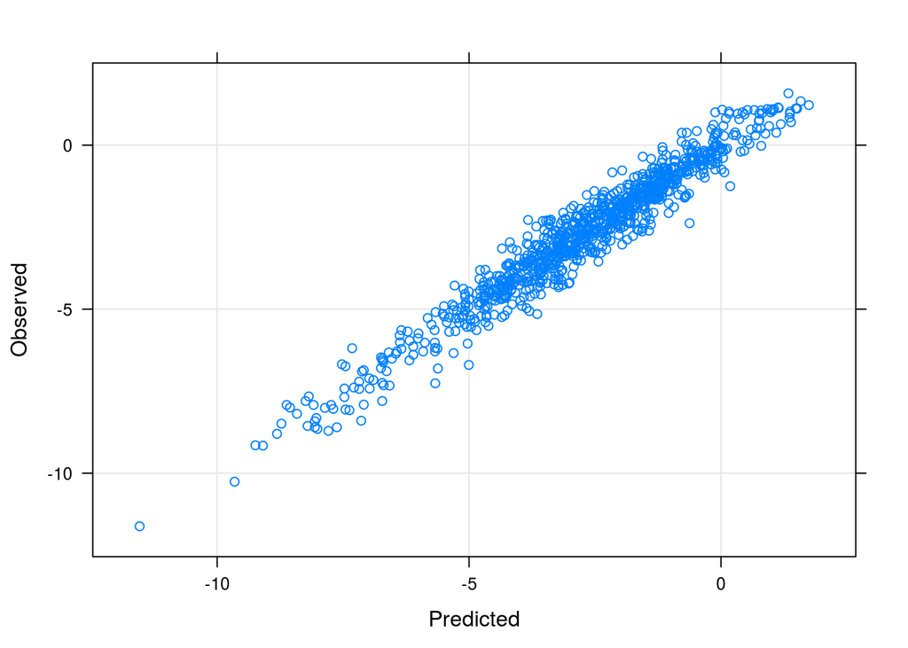

```r
xyplot(solTrainY ~ predict(lmFit1),
       type = c("p", "g"),
       xlab = "Predicted", ylab = "Observed")
```

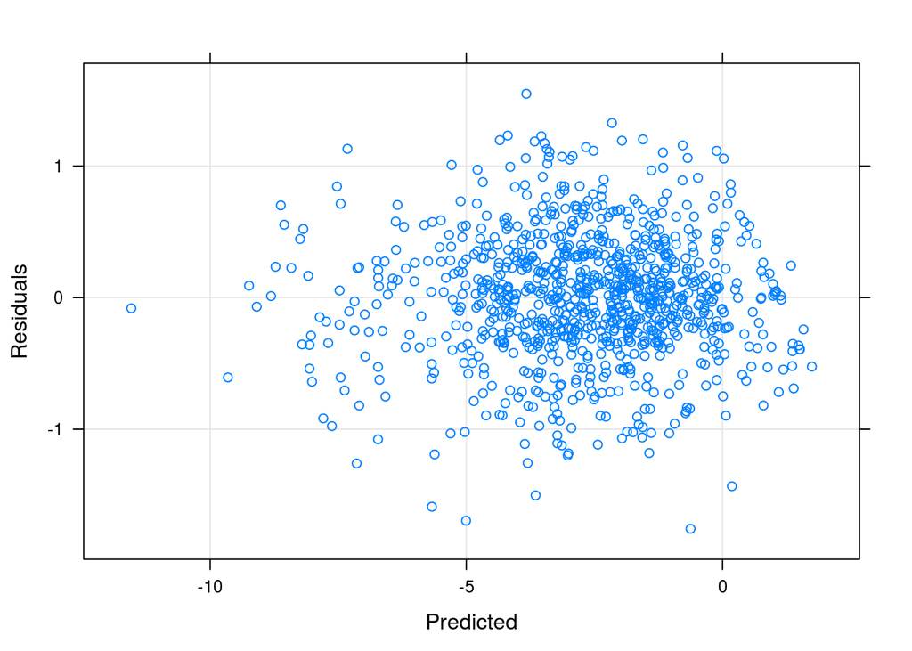

```r
xyplot(resid(lmFit1) ~ predict(lmFit1),
       type = c("p", "g"),
       xlab = "Predicted", ylab = "Residuals")
```

- To build a smaller model without exteremly high predictors:

```r
corThresh <- 0.9
tooHigh <- findCorrelation(cor(solTrainXtrans), corThresh)
corrPred <- names(solTrainXtrans)[tooHigh]
trainXFiltered <- solTrainXtrans[, -tooHigh]
testXFiltered <- solTestXtrans[, -tooHigh]
ncol(testXFiltered)
```

```
## [1] 190
```

```r
# fit
set.seed(100)
lmFiltered <- train(trainXFiltered, solTrainY, method = "lm",
                    trControl = ctrl)
lmFiltered
```

```
## Linear Regression
##
## 951 samples
## 190 predictors
##
## No pre-processing
## Resampling: Cross-Validated (10 fold)
##
## Summary of sample sizes: 856, 856, 856, 856, 856, 855, ...
##
## Resampling results
##
##   RMSE       Rsquared   RMSE SD     Rsquared SD
##   0.7102684  0.8806887  0.07073366  0.03123627
##
##
```

- robust linear regression can be performed using train function via rlm()
- rlm does not allow predictors to be singular (unlike lm())
- to ensure predictors are not singular, pre process with PCA

```r
set.seed(100)
rlmPCA <- train(trainXFiltered, solTrainY,
                method = "rlm",
                preProcess = "pca",
                trControl = ctrl)
rlmPCA
```

```
## Robust Linear Model
##
## 951 samples
## 190 predictors
##
## Pre-processing: principal component signal extraction, scaled, centered
## Resampling: Cross-Validated (10 fold)
##
## Summary of sample sizes: 856, 856, 856, 856, 856, 855, ...
##
## Resampling results
##
##   RMSE       Rsquared   RMSE SD     Rsquared SD
##   0.8309397  0.8366475  0.08198825  0.03147205
##
##
```

```r
# check - does pca option center and scale first? YES
```

```r
#xyplot(solTrainY ~ predict(rlmPCA),
#       type = c("p", "g"),
#       xlab = "Predicted", ylab = "Observed")
#xyplot(resid(lmFit1) ~ predict(rlmPCA),
#       type = c("p", "g"),
#       xlab = "Predicted", ylab = "Residuals")
```

### PLS

- pls package can be used. Contains several algorithms, use method = “pls”, “oscorespls”, “simpls” or “widekernelpls” for caret train() function
- if want to use by itseld, use plsr()

```r
plsFit <- plsr(Solubility ~ ., data = trainingData)

# predictions can be made for a specific number of components, or several values at one tim
predict(plsFit, solTestXtrans[1:5, ], ncomp = 1:2)
```

```
## , , 1 comps
##
##    Solubility
## 20  -1.789335
## 21  -1.427551
## 23  -2.268798
## 25  -2.269782
## 28  -1.867960
##
## , , 2 comps
##
##    Solubility
## 20  0.2520469
## 21  0.3555028
## 23 -1.8795338
## 25 -0.6848584
## 28 -1.5531552
```

- plsr() has options for k-fold or loocv, and which algorithm to use
- may be easier just to use caret train()

```r
set.seed(100)
plsTune <- train(solTrainXtrans, solTrainY,
                 method = "pls",
                 # default grid evaluates components
                 # 1... tuneLength
                 tuneLength = 20,
                 trControl = ctrl,
                 preProc = c("center", "scale"))
plsTune
```

```
## Partial Least Squares
##
## 951 samples
## 228 predictors
##
## Pre-processing: centered, scaled
## Resampling: Cross-Validated (10 fold)
##
## Summary of sample sizes: 856, 856, 856, 856, 856, 855, ...
##
## Resampling results across tuning parameters:
##
##   ncomp  RMSE       Rsquared   RMSE SD     Rsquared SD
##    1     1.2850871  0.6090640  0.12165159  0.06719973
##    2     1.0570085  0.7392463  0.11229660  0.04863782
##    3     0.9368209  0.7947554  0.10121065  0.03805391
##    4     0.8623101  0.8239703  0.07666168  0.03268768
##    5     0.8163891  0.8405983  0.08705784  0.03663938
##    6     0.7827983  0.8533939  0.07807138  0.03128697
##    7     0.7579728  0.8627742  0.07311825  0.02784864
##    8     0.7419485  0.8687634  0.06298472  0.02975784
##    9     0.7346041  0.8712798  0.06310733  0.02900737
##   10     0.7267141  0.8750312  0.05142933  0.02194222
##   11     0.7185386  0.8778707  0.05173647  0.02166838
##   12     0.7180133  0.8780477  0.05722694  0.02165606
##   13     0.7154710  0.8787691  0.05678323  0.02144809
##   14     0.7114484  0.8803229  0.05532633  0.02056963
##   15     0.7106361  0.8800336  0.06058449  0.02362864
##   16     0.7068092  0.8812746  0.06135602  0.02508870
##   17     0.7047825  0.8818817  0.06021996  0.02549624
##   18     0.7061302  0.8812863  0.06168560  0.02696471
##   19     0.7030984  0.8824753  0.06572861  0.02735154
##   20     0.7059551  0.8817962  0.06181828  0.02616524
##
## RMSE was used to select the optimal model using  the smallest value.
## The final value used for the model was ncomp = 19.
```

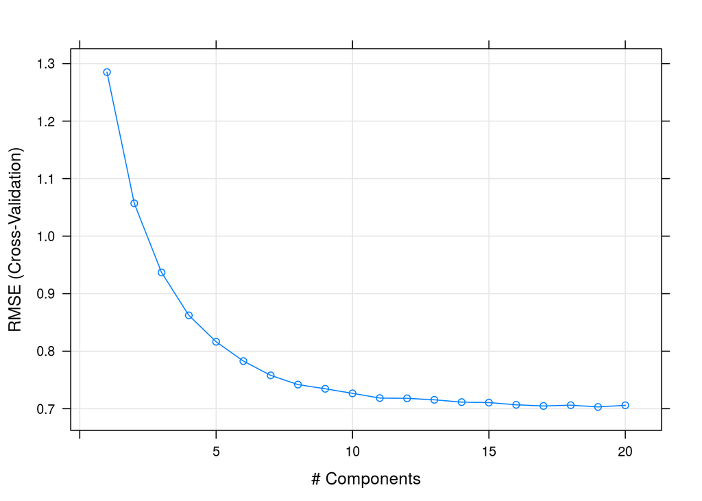

```r
# can plot eg ncomponents vs rmse for instructive plots
xyplot(plsTune$results$RMSE ~ plsTune$results$ncomp,
       xlab = "# Components",
       ylab = "RMSE (Cross-Validation)",
       type = c("o", "g"))
```

### Penalised Regression Methods

- ridge regression models can be create using lm.ridge() function in MASS packae or the enet() function in elasticnet package
- when call enet(), lambda sepcifies the the ridge-regression penalty

```r
ridgeModel <- enet(x = as.matrix(solTrainXtrans), y = solTrainY,
                   lambda = 0.001)
```

- remember that the elastic net has both ridge and lasso penalties, ridge has only ridge penalty
- predict() function for enet onjects generate values for one or more penalty simultaniously

```r
# s = 1 argument and mode = "fraction" lets us specify how the amount of penalization
# # is defined, eg a value of 1 corresponds to a fraction of 1 - the full solution
# predictor data must be a matrix
ridgePred <- predict(ridgeModel, newx = as.matrix(solTestXtrans),
                     s = 1, mode = "fraction", type = "fit")
head(ridgePred$fit)
```

```
##          20          21          23          25          28          31
##  0.96795590  0.06918538 -0.54365077  0.96072014 -0.03594693  1.59284535
```

- to tune over penalty, use the caret train() method

```r
ridgeGrid <- data.frame(.lambda = seq(0, 0.1, length=15))
set.seed(100)
ridgeRegFit <- train(solTrainXtrans, solTrainY,
                     method = "ridge",
                     # fit model over many penalty values
                     tuneGrid = ridgeGrid,
                     trControl = ctrl,
                     # put predictors on the same scale
                     preProc = c("center", "scale"))
ridgeRegFit
```

```
## Ridge Regression
##
## 951 samples
## 228 predictors
##
## Pre-processing: centered, scaled
## Resampling: Cross-Validated (10 fold)
##
## Summary of sample sizes: 856, 856, 856, 856, 856, 855, ...
##
## Resampling results across tuning parameters:
##
##   lambda       RMSE       Rsquared   RMSE SD     Rsquared SD
##   0.000000000  0.7089825  0.8820788  0.06931678  0.02591012
##   0.007142857  0.6957508  0.8853990  0.06564101  0.02691782
##   0.014285714  0.6894049  0.8874979  0.06305758  0.02557905
##   0.021428571  0.6873000  0.8883313  0.06168688  0.02483717
##   0.028571429  0.6870753  0.8886212  0.06071996  0.02435327
##   0.035714286  0.6879091  0.8886211  0.05995477  0.02401865
##   0.042857143  0.6894240  0.8884481  0.05931592  0.02378380
##   0.050000000  0.6914183  0.8881655  0.05876738  0.02362115
##   0.057142857  0.6937736  0.8878107  0.05828870  0.02351328
##   0.064285714  0.6964152  0.8874072  0.05786687  0.02344821
##   0.071428571  0.6992939  0.8869709  0.05749294  0.02341724
##   0.078571429  0.7023759  0.8865125  0.05716045  0.02341381
##   0.085714286  0.7056371  0.8860394  0.05686454  0.02343283
##   0.092857143  0.7090600  0.8855571  0.05660152  0.02347026
##   0.100000000  0.7126315  0.8850695  0.05636849  0.02352289
##
## RMSE was used to select the optimal model using  the smallest value.
## The final value used for the model was lambda = 0.02857143.
```

- lasso model can be estimated using a number of different functions- lars package contains lars() function, elasticnet has enet() and glmnet has enet(). syntax for these functions is very similar

```r
# predictor must be a matrix
# predictors should be centered and scaled prior to modelling
# normalize argument handles this automitically
# setting lambda to 0 fits the lasso model (it is the ridge penalty)
# lasso penalty does not need to be sepcified until time of prediction
enetModel <- enet(x = as.matrix(solTrainXtrans), y = solTrainY,
                   lambda = 0.01, normalize = TRUE)

enetPred <- predict(enetModel, newx = as.matrix(solTestXtrans),
                    s = 0.1, mode = "fraction",
                    type ="fit")
names(enetPred)
```

```
## [1] "s"        "fraction" "mode"     "fit"
```

```r
# predicted valued held in fit component of object
head(enetPred$fit)
```

```
##          20          21          23          25          28          31
## -0.60186178 -0.42226814 -1.20465564 -1.23652963 -1.25023517 -0.05587631
```

```r
# to determine which coefficients used in model, predict method used
# with type = "coefficients"
enetCoef <- predict(enetModel, newx = as.matrix(solTestXtrans),
                    s = 0.1, mode = "fraction",
                    type = "coefficients")
tail(enetCoef$coefficients)
```

```
##       NumChlorine        NumHalogen          NumRings HydrophilicFactor
##        0.00000000        0.00000000        0.00000000        0.12678967
##      SurfaceArea1      SurfaceArea2
##        0.09035596        0.00000000
```

- as before, we can use caret train() to investigate multiple values of s

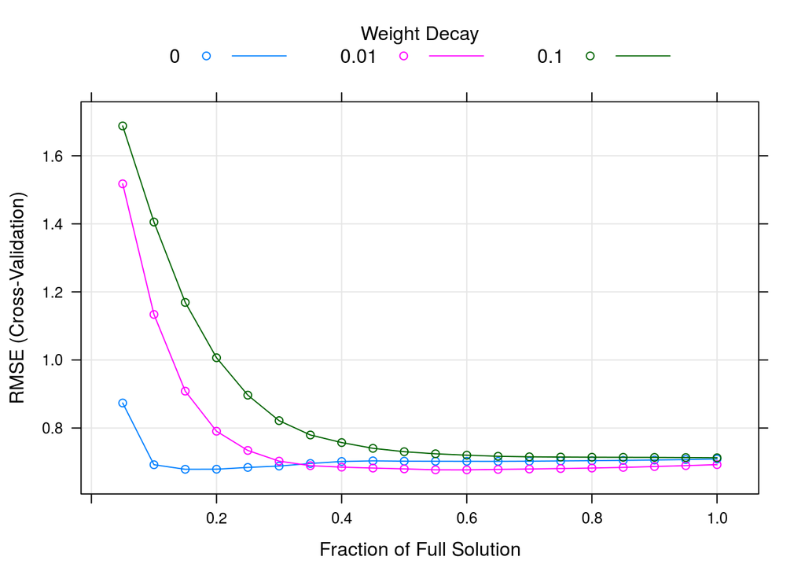

```r
enetGrid <- expand.grid(.lambda = c(0, 0.01, 0.1),
                         .fraction = seq(0.05, 1, length = 20))
set.seed(100)
enetTune <- train(solTrainXtrans, solTrainY,
                  method = "enet",
                  tuneGrid = enetGrid,
                  trControl = ctrl,
                  preProc = c("center", "scale"))
plot(enetTune)
```